# Ford Gobike Analysis

## Preliminary Wrangling

```python
# import all packages and set plots to be embedded inline
import numpy as np
import pandas as pd
import matplotlib.pyplot as plt
import seaborn as sb

%matplotlib inline
```

```python
df = pd.read_csv("201902-fordgobike-tripdata.csv")
df.head()
```

|  | duration_sec | start_time | end_time | start_station_id | start_station_name | start_station_latitude | start_station_longitude | end_station_id | end_station_name | end_station_latitude | end_station_longitude | bike_id | user_type | member_birth_year | member_gender | bike_share_for_all_trip |
| --- | --- | --- | --- | --- | --- | --- | --- | --- | --- | --- | --- | --- | --- | --- | --- | --- |
| 0 | 52185 | 2019-02-28 17:32:10.1450 | 2019-03-01 08:01:55.9750 | 21.0 | Montgomery St BART Station (Market St at 2nd St) | 37.789625 | -122.400811 | 13.0 | Commercial St at Montgomery St | 37.794231 | -122.402923 | 4902 | Customer | 1984.0 | Male | No |
| 1 | 42521 | 2019-02-28 18:53:21.7890 | 2019-03-01 06:42:03.0560 | 23.0 | The Embarcadero at Steuart St | 37.791464 | -122.391034 | 81.0 | Berry St at 4th St | 37.775880 | -122.393170 | 2535 | Customer | NaN | NaN | No |
| 2 | 61854 | 2019-02-28 12:13:13.2180 | 2019-03-01 05:24:08.1460 | 86.0 | Market St at Dolores St | 37.769305 | -122.426826 | 3.0 | Powell St BART Station (Market St at 4th St) | 37.786375 | -122.404904 | 5905 | Customer | 1972.0 | Male | No |
| 3 | 36490 | 2019-02-28 17:54:26.0100 | 2019-03-01 04:02:36.8420 | 375.0 | Grove St at Masonic Ave | 37.774836 | -122.446546 | 70.0 | Central Ave at Fell St | 37.773311 | -122.444293 | 6638 | Subscriber | 1989.0 | Other | No |
| 4 | 1585 | 2019-02-28 23:54:18.5490 | 2019-03-01 00:20:44.0740 | 7.0 | Frank H Ogawa Plaza | 37.804562 | -122.271738 | 222.0 | 10th Ave at E 15th St | 37.792714 | -122.248780 | 4898 | Subscriber | 1974.0 | Male | Yes |

```python
df.info()
```

```
<class 'pandas.core.frame.DataFrame'>
RangeIndex: 183412 entries, 0 to 183411
Data columns (total 16 columns):
 #   Column                   Non-Null Count   Dtype
---  ------                   --------------   -----
 0   duration_sec             183412 non-null  int64
 1   start_time               183412 non-null  object
 2   end_time                 183412 non-null  object
 3   start_station_id         183215 non-null  float64
 4   start_station_name       183215 non-null  object
 5   start_station_latitude   183412 non-null  float64
 6   start_station_longitude  183412 non-null  float64
 7   end_station_id           183215 non-null  float64
 8   end_station_name         183215 non-null  object
 9   end_station_latitude     183412 non-null  float64
 10  end_station_longitude    183412 non-null  float64
 11  bike_id                  183412 non-null  int64
 12  user_type                183412 non-null  object
 13  member_birth_year        175147 non-null  float64
 14  member_gender            175147 non-null  object
 15  bike_share_for_all_trip  183412 non-null  object
dtypes: float64(7), int64(2), object(7)
memory usage: 22.4+ MB
```

converting bike_share_for_all_trip to boolean

```python
df.bike_share_for_all_trip = (df.bike_share_for_all_trip == 'Yes')
df.head()
```

|  | duration_sec | start_time | end_time | start_station_id | start_station_name | start_station_latitude | start_station_longitude | end_station_id | end_station_name | end_station_latitude | end_station_longitude | bike_id | user_type | member_birth_year | member_gender | bike_share_for_all_trip |
| --- | --- | --- | --- | --- | --- | --- | --- | --- | --- | --- | --- | --- | --- | --- | --- | --- |
| 0 | 52185 | 2019-02-28 17:32:10.1450 | 2019-03-01 08:01:55.9750 | 21.0 | Montgomery St BART Station (Market St at 2nd St) | 37.789625 | -122.400811 | 13.0 | Commercial St at Montgomery St | 37.794231 | -122.402923 | 4902 | Customer | 1984.0 | Male | False |
| 1 | 42521 | 2019-02-28 18:53:21.7890 | 2019-03-01 06:42:03.0560 | 23.0 | The Embarcadero at Steuart St | 37.791464 | -122.391034 | 81.0 | Berry St at 4th St | 37.775880 | -122.393170 | 2535 | Customer | NaN | NaN | False |
| 2 | 61854 | 2019-02-28 12:13:13.2180 | 2019-03-01 05:24:08.1460 | 86.0 | Market St at Dolores St | 37.769305 | -122.426826 | 3.0 | Powell St BART Station (Market St at 4th St) | 37.786375 | -122.404904 | 5905 | Customer | 1972.0 | Male | False |
| 3 | 36490 | 2019-02-28 17:54:26.0100 | 2019-03-01 04:02:36.8420 | 375.0 | Grove St at Masonic Ave | 37.774836 | -122.446546 | 70.0 | Central Ave at Fell St | 37.773311 | -122.444293 | 6638 | Subscriber | 1989.0 | Other | False |
| 4 | 1585 | 2019-02-28 23:54:18.5490 | 2019-03-01 00:20:44.0740 | 7.0 | Frank H Ogawa Plaza | 37.804562 | -122.271738 | 222.0 | 10th Ave at E 15th St | 37.792714 | -122.248780 | 4898 | Subscriber | 1974.0 | Male | True |

converting start and end time to date time

```python
df.start_time = pd.to_datetime(df.start_time)
df.end_time = pd.to_datetime(df.end_time)
```

converting end and start station id and member birth year to string

```python
df.end_station_id  = df.end_station_id.fillna(-1)
df.start_station_id  = df.start_station_id.fillna(-1)
df.member_birth_year  = df.member_birth_year.fillna(-1)

df.bike_id = df.bike_id.astype("str")
df.end_station_id  = df.end_station_id.astype("int").astype("str")
df.start_station_id  = df.start_station_id.astype("int").astype("str")
df.member_birth_year  = df.member_birth_year.astype("int").astype("str")
```

```python
df.head()
```

|  | duration_sec | start_time | end_time | start_station_id | start_station_name | start_station_latitude | start_station_longitude | end_station_id | end_station_name | end_station_latitude | end_station_longitude | bike_id | user_type | member_birth_year | member_gender | bike_share_for_all_trip |
| --- | --- | --- | --- | --- | --- | --- | --- | --- | --- | --- | --- | --- | --- | --- | --- | --- |
| 0 | 52185 | 2019-02-28 17:32:10.145 | 2019-03-01 08:01:55.975 | 21 | Montgomery St BART Station (Market St at 2nd St) | 37.789625 | -122.400811 | 13 | Commercial St at Montgomery St | 37.794231 | -122.402923 | 4902 | Customer | 1984 | Male | False |
| 1 | 42521 | 2019-02-28 18:53:21.789 | 2019-03-01 06:42:03.056 | 23 | The Embarcadero at Steuart St | 37.791464 | -122.391034 | 81 | Berry St at 4th St | 37.775880 | -122.393170 | 2535 | Customer | -1 | NaN | False |
| 2 | 61854 | 2019-02-28 12:13:13.218 | 2019-03-01 05:24:08.146 | 86 | Market St at Dolores St | 37.769305 | -122.426826 | 3 | Powell St BART Station (Market St at 4th St) | 37.786375 | -122.404904 | 5905 | Customer | 1972 | Male | False |
| 3 | 36490 | 2019-02-28 17:54:26.010 | 2019-03-01 04:02:36.842 | 375 | Grove St at Masonic Ave | 37.774836 | -122.446546 | 70 | Central Ave at Fell St | 37.773311 | -122.444293 | 6638 | Subscriber | 1989 | Other | False |
| 4 | 1585 | 2019-02-28 23:54:18.549 | 2019-03-01 00:20:44.074 | 7 | Frank H Ogawa Plaza | 37.804562 | -122.271738 | 222 | 10th Ave at E 15th St | 37.792714 | -122.248780 | 4898 | Subscriber | 1974 | Male | True |

```python
df.info()
```

```
<class 'pandas.core.frame.DataFrame'>
RangeIndex: 183412 entries, 0 to 183411
Data columns (total 16 columns):
 #   Column                   Non-Null Count   Dtype
---  ------                   --------------   -----
 0   duration_sec             183412 non-null  int64
 1   start_time               183412 non-null  datetime64[ns]
 2   end_time                 183412 non-null  datetime64[ns]
 3   start_station_id         183412 non-null  object
 4   start_station_name       183215 non-null  object
 5   start_station_latitude   183412 non-null  float64
 6   start_station_longitude  183412 non-null  float64
 7   end_station_id           183412 non-null  object
 8   end_station_name         183215 non-null  object
 9   end_station_latitude     183412 non-null  float64
 10  end_station_longitude    183412 non-null  float64
 11  bike_id                  183412 non-null  object
 12  user_type                183412 non-null  object
 13  member_birth_year        183412 non-null  object
 14  member_gender            175147 non-null  object
 15  bike_share_for_all_trip  183412 non-null  bool
dtypes: bool(1), datetime64[ns](2), float64(4), int64(1), object(8)
memory usage: 21.2+ MB
```

### What is the structure of your dataset?

> there are 183,412 row in this dataset with 16 column (5 numeric, 8 string, 2 datetime and 1 boolean).

### What is/are the main feature(s) of interest in your dataset?

> I want to focus on the duration of each trip and it's relation with user type, gender, age , start and end stations.

### What features in the dataset do you think will help support your investigation into your feature(s) of interest?

> I think that the duration_sec is the most important feature and it's strongly related to the other features.

## Univariate Exploration

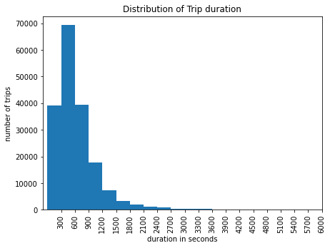

```python
bins = np.arange(0,df['duration_sec'].max()+300,300)
plt.figure(figsize=[7,5])
plt.hist(data = df, x = 'duration_sec',bins = bins)

plt.title("Distribution of Trip duration")
plt.xlabel("duration in seconds")
plt.ylabel("number of trips")
plt.xlim([-100,6000])
plt.xticks(np.arange(300,6000+300,300),rotation = 90)
plt.show()
```

> we should do a logarithmic scale because the histogram is skewed.

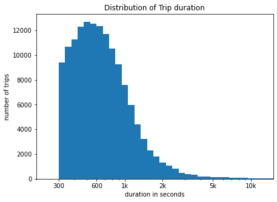

```python
bins = 10 ** np.arange(np.log10(300), np.log10(df['duration_sec'].max()) + 0.05, 0.05)
plt.figure(figsize=[7,5])
plt.hist(data = df, x = 'duration_sec',bins = bins)

plt.title("Distribution of Trip duration")
plt.xlabel("duration in seconds")
plt.ylabel("number of trips")
plt.xlim([200,15000])
plt.xscale('log')
plt.xticks([300, 600, 1e3, 2e3, 5e3, 1e4], [300, 600, '1k', '2k', '5k', '10k'])
plt.show()
```

> most trips durations are between 300 sec and 1000 sec (around 8000 trip to 12000 trip) with beak 600 sec.

Now I will see the Distribution of end and start stations.

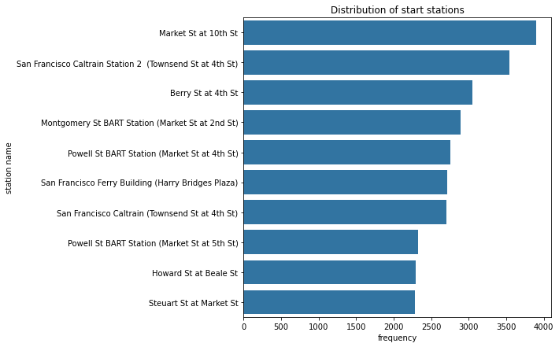

```python
base_color = sb.color_palette()[0]
order = df.start_station_name.value_counts().index[:10]
plt.figure(figsize=(7, 7))
sb.countplot(data = df, y = "start_station_name",color = base_color, order = order)
plt.title("Distribution of start stations")
plt.ylabel("station name")
plt.xlabel("frequency")
plt.show()
```

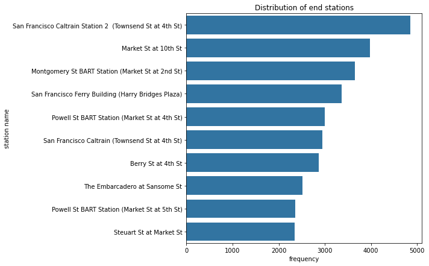

```python
base_color = sb.color_palette()[0]
order = df.end_station_name.value_counts().index[:10]
plt.figure(figsize=(7, 7))
sb.countplot(data = df, y = "end_station_name",color = base_color, order = order)
plt.title("Distribution of end stations")
plt.ylabel("station name")
plt.xlabel("frequency")
plt.show()
```

```python
df['trip'] = "From " + df['start_station_name'] + " to " + df['end_station_name']
```

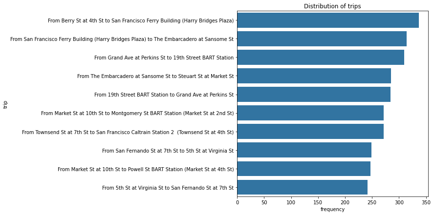

```python
base_color = sb.color_palette()[0]
order = df.trip.value_counts().index[:10]
plt.figure(figsize=(7, 7))
sb.countplot(data = df, y = "trip",color = base_color, order = order)
plt.title("Distribution of trips")
plt.ylabel("trip")
plt.xlabel("frequency")
plt.show()
```

> as we can see that From Berry St at 4th St to San Francisco Ferry Building (Harry Bridges Plaza) is the most frequent trip.

let's see the distribution of the users ages.

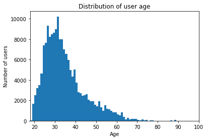

```python
temp = df[df.member_birth_year != '-1']
temp.member_birth_year = temp.member_birth_year
temp['age'] = 2019 - temp.member_birth_year.astype(int)


bins = np.arange(0, temp['age'].max() + 1, 1)

plt.hist(data = temp, x = 'age', bins = bins)
plt.title('Distribution of user age')
plt.xlabel('Age')
plt.ylabel('Number of users')
plt.xlim([18,100])
plt.show()
```

> the number of users is increasing till the age of 30 then decreasing, Most users are between 20 and 40 years old with two peaks around 30 and 26 years old.

what is the distribution of user types ?

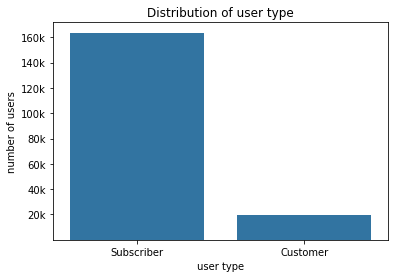

```python
base_color = sb.color_palette()[0]
sb.countplot(data = df, x = "user_type",color = base_color, order = ['Subscriber', 'Customer'])
plt.title("Distribution of user type")
plt.ylabel("number of users")
plt.xlabel("user type")
plt.yticks([20000,40000,60000,80000,100000,120000,140000,160000],['20k','40k','60k','80k','100k','120k','140k','160k'])
plt.show()
```

> most users are subscribers (around 160k vs 20k).

does gender make trips equally ?

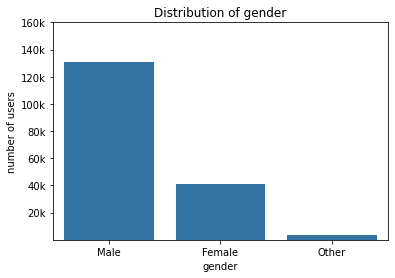

```python
base_color = sb.color_palette()[0]
sb.countplot(data = df, x = "member_gender",color = base_color, order = ['Male', 'Female', 'Other'])
plt.title("Distribution of gender")
plt.ylabel("number of users")
plt.xlabel("gender")
plt.yticks([20000,40000,60000,80000,100000,120000,140000,160000],['20k','40k','60k','80k','100k','120k','140k','160k'])
plt.show()
```

> most users are male (around 130k vs 40k) so genders aren't equally in trips.

### Discuss the distribution(s) of your variable(s) of interest. Were there any unusual points? Did you need to perform any transformations?

> in the age distribution there was a beak in 26 years old then decreasing then increasing which was unusual, I performed a transformation in the duration distribution because the histogram was right skewed.

### Of the features you investigated, were there any unusual distributions? Did you perform any operations on the data to tidy, adjust, or change the form of the data? If so, why did you do this?

> in the age distribution I substracted the birth year from 2019 to calculate the age , I sliced the start and end stations distrubtions because it's too large.

## Bivariate Exploration

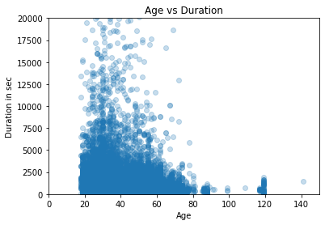

```python
plt.scatter(temp['age'], temp['duration_sec'], alpha = 0.25)
plt.xlim([0,150])
plt.ylim([0,20000])
plt.title('Age vs Duration')
plt.xlabel('Age')
plt.ylabel('Duration in sec')
plt.show()
```

> most trip durations are lower than 7500 sec and most ages are between 20 and 40 and there is a person with age 140 which is propably a mistake.

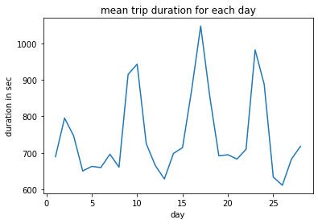

```python
t = df
t['day'] = df['start_time'].dt.day
t = t.groupby('day')['duration_sec']

sb.lineplot(y = t.agg('mean'), x = t.agg('mean').index)
plt.title('mean trip duration for each day')
plt.xlabel('day')
plt.ylabel('duration in sec')
plt.show()
```

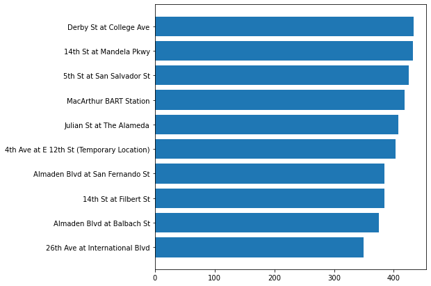

```python
s = df.groupby('start_station_name')['duration_sec']
s = s.mean().sort_values()[:10]

plt.figure(figsize=[7,7])
plt.barh(s.index, s.values)
plt.show()
```

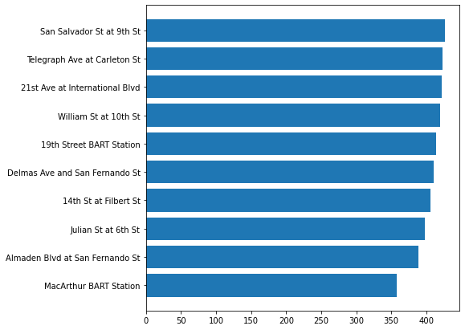

```python
e = df.groupby('end_station_name')['duration_sec']
e = e.mean().sort_values()[:10]

plt.figure(figsize=[7,7])
plt.barh(e.index, e.values)
plt.show()
```

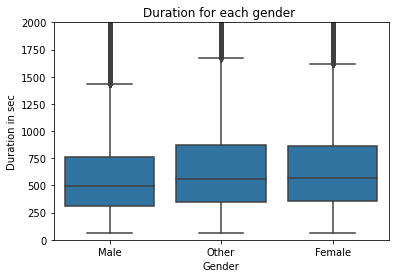

```python
base_color = sb.color_palette()[0]
sb.boxplot(data = df, x = 'member_gender', y = 'duration_sec', color = base_color)
plt.title('Duration for each gender ')
plt.ylim([0,2000])
plt.xlabel('Gender')
plt.ylabel('Duration in sec')
plt.show()
```

> the outliers are too many and have large values so I cut it to 2000 sec.

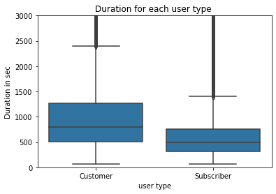

```python
base_color = sb.color_palette()[0]
sb.boxplot(data = df, x = 'user_type', y = 'duration_sec', color = base_color)
plt.title('Duration for each user type ')
plt.ylim([0,3000])
plt.xlabel('user type')
plt.ylabel('Duration in sec')
plt.show()
```

> the outliers are too many and have large values so I cut it to 3000 sec, we can see the customers tend to make longer trips than subscribers.

### Talk about some of the relationships you observed in this part of the investigation. How did the feature(s) of interest vary with other features in the dataset?

> trip duration is dependent on the age (people between 20 and 40 years old trip duration is higher than the older ages) and dependent on the user type.

## Multivariate Exploration

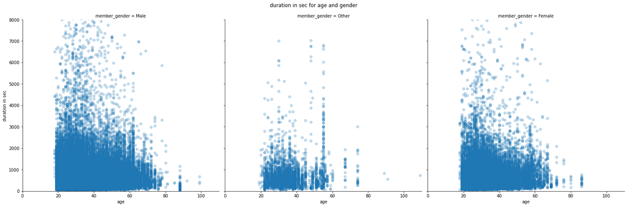

```python
gender = sb.FacetGrid(data = temp, col = 'member_gender', height = 7, ylim=[0,8000], xlim = [0,110])
gender.map(plt.scatter, 'age', 'duration_sec', alpha = 0.25)
gender.fig.subplots_adjust(top = 0.9)
gender.fig.suptitle('duration in sec for age and gender')
gender.set_ylabels('duration in sec')
gender.set_xlabels('age')
plt.show()
```

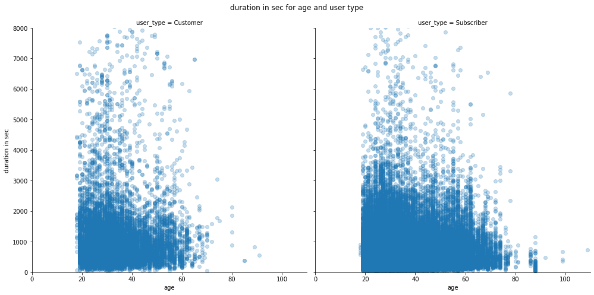

```python
gender = sb.FacetGrid(data = temp, col = 'user_type', height = 7, ylim=[0,8000], xlim = [0,110])
gender.map(plt.scatter, 'age', 'duration_sec', alpha = 0.25)
gender.fig.subplots_adjust(top = 0.9)
gender.fig.suptitle('duration in sec for age and user type')
gender.set_ylabels('duration in sec')
gender.set_xlabels('age')
plt.show()
```

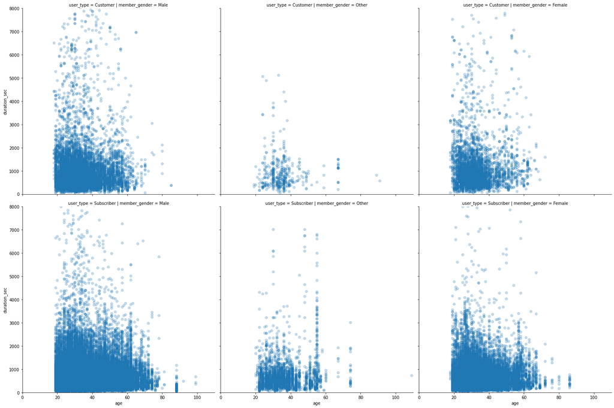

```python
gender = sb.FacetGrid(data = temp, col = 'member_gender', row = 'user_type', height = 7, ylim=[0,8000], xlim = [0,110])
gender.map(plt.scatter, 'age', 'duration_sec', alpha = 0.25)
```